# Data-analytiikka - Harjoitus 7

Huomaa, että tehtävät tulee palauttaa html-tiedostona, jossa näkyvät sekä koodisolujen sisällöt että tulosteet. Notebookin saat html-tiedostoksi valitsemalla File -> Download as -> HTML. Tehtävien vastaukset voi tehdä yhteen tai useampaan koodisoluun.

**Opiskelijan nimi:** Eino Puttonen

**Opiskelijanumero:** AB7200

## Muuttujien välinen riippuvuus

Lue datasetti 'electricity_consumption_and_temperature_01012022_31122022.csv' urlista url = 'https://student.labranet.jamk.fi/~ajota/Datasets/electricity_consumption_and_temperature_01012022_31122022.csv' Kyseessä on korjattu datasetti, joten puuttuvien arvojen tai outliereiden korjausta ei tarvitse tehdä.

1. Tee Sähkönkulutus Suomessa ja Ilman lämpötila (degC) -arvoista hajontakaavio. Mieti kumpi riippuu kummasta ja miten muuttujat kannattaa akseleille asettaa. Lisää akseleille selitteet ja muuta pisteiden läpinäkyvyydeksi 0.3 siten, että havaintojen jakauma erottuu paremmin.
2. Laske Sähkönkulutus Suomessa ja Ilman lämpötila (degC) -arvojen välinen korrelaatio. Miksi Pearsonin korrelaatiokerroin ei näytä vahvempaa korrelaatiota, vaikka kuvaajassa näkyy selvä syy-yhteys?

Pisteytys: 0.75 p

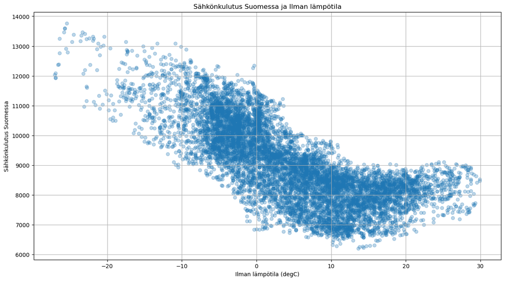

```python
import pandas as pd
import matplotlib.pyplot as plt
import seaborn as sns
import numpy as np

df_elec = pd.read_csv('https://student.labranet.jamk.fi/~ajota/Datasets/electricity_consumption_and_temperature_01012022_31122022.csv')
#df_elec.head()
#kokeilemalla kuvan koko
plt.figure(figsize=(15, 8))
#lämpötilan vaikutus sähkönkulutukseen, pisteiden läpinäkyvyys alpha
plt.scatter(df_elec['Ilman lämpötila (degC)'], df_elec['Sähkönkulutus Suomessa'], alpha=0.3)
#otskko
plt.title('Sähkönkulutus Suomessa ja Ilman lämpötila')
#akselitason selitteet
plt.xlabel('Ilman lämpötila (degC)')
plt.ylabel('Sähkönkulutus Suomessa')
#gridin luettavuuden kannalta
plt.grid(True)
```

```python
#korrelaatio läpmötilan suhde sähkön kulutuksee
correl = df_elec['Ilman lämpötila (degC)'].corr(df_elec['Sähkönkulutus Suomessa'])
print('Pearsonin korrelaatiokerroin aineistolle: ', correl)
'''Sähkön kulutus ei riipu pelkästään säästä, vaan myös esim. siitä onko arkipäivä tai mitä kello on'''
```

```
Pearsonin korrelaatiokerroin aineistolle:  -0.7463789228191313
```

```
'Sähkön kulutus ei riipu pelkästään säästä, vaan myös esim. siitä onko arkipäivä tai mitä kello on'
```

## Uudelleen näytteistäminen

Tiedostossa 'dos_attack_unsw_nb15.csv' on synteettistä, tutkimustarkoituksiin luotua dataa, joka kuvaa DoS-hyökkäyksiä. Voit lukea datan urlista 'https://student.labranet.jamk.fi/~ajota/Datasets/dos_attack_unsw_nb15.csv'

Visualisoi yhteyksien määrä ajan suhteen. Aikana voit käyttää 'record start time' -saraketta ja yhteydenottojen lukumäärän laskea esimerkiksi '0 for normal and 1 for attack records' -sarakkeen avulla.

Mieti/testaa järkevä näytteistysväli, (5 s, 10 s, 30 s, 60 s) jolla yhteydenottojen määrää kannattaa visualisoida.

Pisteytys: 1 p

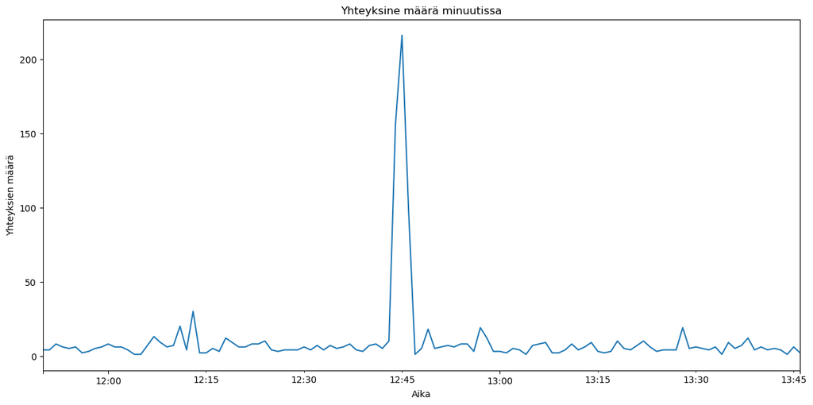

```python
# Vastaus
ddos = pd.read_csv( 'https://student.labranet.jamk.fi/~ajota/Datasets/dos_attack_unsw_nb15.csv')
ddos.dtypes
#tehdään record start timesta aikasarake
ddos['record start time'] = pd.to_datetime(ddos['record start time'])
#tehdään date time indexi, koska resample sitä kinuaa
ddos.set_index('record start time', inplace=True)
#valitaan näytteistysväli ja miten yhteyksien määrä lasketaan.
connections_in_minute = ddos.resample('60s').size()

#kuvan koko
plt.figure(figsize=(15,7))
#luodaan connections in minute aiksarjalle kaavio
connections_in_minute.plot()
#otiskko
plt.title('Yhteyksine määrä minuutissa')
plt.xlabel('Aika')
plt.ylabel('Yhteyksien määrä')
plt.show()
```

## Muutoksen visualisointia

Alla olevista urleista saat luettua Suomen sähkönkulutuksen vuosilta 2021 ja 2022. 'https://student.labranet.jamk.fi/~ajota/Datasets/electricity_consumption_01012021_31122021.csv' 'https://student.labranet.jamk.fi/~ajota/Datasets/electricity_consumption_and_temperature_01012022_31122022.csv'.

Yhdistä DataFramet yhdeksi DataFrameksi dfe2122 kuukauden ja päivän mukaan. Aseta niille sarakkeille suffiksit ' 2021' ja ' 2022', jotka ovat samat molemmissa DataFrameissa, mutta joita ei käytetä yhdistämiseen.

Laske sitten sähkönkulutuksen mediaanit kuukausittain.

Visualisoi vuosien 2021 ja 2022 sähkönkulutuksen mediaanit kuukausittain samaan pylväskaavioon (saman kuukauden sähkönkulutukset tulevat kaavioon vierekkäin). Lisää kaavioon otsikko "Sähkönkulutuksen mediaani vuosina 2021 ja 2022", selitteet sekä arvoille että y- ja x-akseleille.

Pisteytys: 0.75 p

[output not shown]

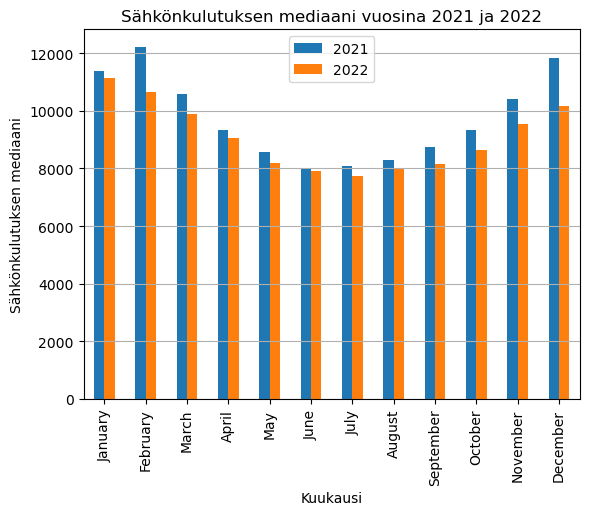

```python
# Vastaus

url1 = 'https://student.labranet.jamk.fi/~ajota/Datasets/electricity_consumption_01012021_31122021.csv'
url2 = 'https://student.labranet.jamk.fi/~ajota/Datasets/electricity_consumption_and_temperature_01012022_31122022.csv'

dfe2021 = pd.read_csv(url1, index_col=0)
dfe2022 = pd.read_csv(url2, index_col=0)

#mergetään df_t
dfe2122 = pd.merge(dfe2021, dfe2022, left_index=True, right_index=True, suffixes=('_2021', '_2022'))

# datetimesarakeet vuosille 2021 ja 2022
dfe2122['date_2021'] = pd.to_datetime(dfe2122['Alkuaika UTC_2021'].str.split(' ').str[0])
dfe2122['date_2022'] = pd.to_datetime(dfe2122['Alkuaika UTC_2022'].str.split(' ').str[0])

#aikasarakeet indeksiksi
dfe2122.set_index(['date_2021', 'date_2022'], inplace=True)
#monitasoisen indekin purku
dfe2122.index = dfe2122.index.get_level_values(0)

#valitaan halutut sarakkeet taulukkoon
sk_suomessa = dfe2122[['Sähkönkulutus Suomessa_2021', 'Sähkönkulutus Suomessa_2022']]
#lasketaan niille mediaanit
keskikulutus = sk_suomessa.resample('M').median()
#display(keskikulutus)
#kuva
plt.figure(figsize=(12, 6))
#pylväs
keskikulutus.plot(kind='bar')
plt.title('Sähkönkulutuksen mediaani vuosina 2021 ja 2022')
plt.xlabel('Kuukausi')
plt.ylabel('Sähkönkulutuksen mediaani')
#pylväiden kuvaukset
plt.legend(['2021', '2022'])
plt.grid(axis='y')
#plt.show()
#timestampit kuukauden nimiksi
plt.xticks(range(len(keskikulutus.index)), [month.strftime('%B') for month in keskikulutus.index])
plt.show()
```